# Chocolate

```r
# Make a new column with Region as a factor


Chocolate2 <- Chocolate %>%
  mutate(Region = factor(Location))

levels(Chocolate2$Region) <- list(
  'South America' = c("Argentina", "Bolivia", "Brazil", "Chile", "Colombia", "Ecuador", "Eucador", "Guyana", "Paraguay", "Peru", "Suriname", "Uruguay", "Venezuela"),
  Oceania = c("Australia", "New Zealand", "Fiji"),
  'North America' = c("Canada", "Costa Rica", "Dominican Republic", "Domincan Republic", "Grenada", "Guatemala", "Honduras", "Mexico", "Nicaragua", "Niacragua", "St. Lucia", "U.S.A.", "Martinique", "Puerto Rico"),
  Europe = c("Austria", "Belgium", "Czech Republic", "Denmark", "Finland", "France", "Germany", "Hungary", "Iceland", "Ireland", "Italy", "Lithuania", "Netherlands", "Poland", "Portugal", "Russia", "Spain", "Sweden", "Switzerland", "Amsterdam", "Wales", "U.K.", "Scotland"),
  Asia = c("India", "Israel", "Japan", "Philippines", "Russia", "Singapore", "South Korea", "Vietnam"),
  Africa = c("Algeria", "Ghana", "Madagascar", "Sao Tome and Principe", "Sao Tome", "South Africa"))
```

## Background

[Chocolate Bar Ratings](https://www.kaggle.com/rtatman/chocolate-bar-ratings/data) contains information and the ratings by experts of more than 1700 choclate bars, including details such as the company manufacturing the chocolate, the percent of cacao, the manufacturing location. Using the data, the question, “Do chocolate bars from manufactured in different regions have different distributions of ratings?”

Rating: Expert rating for the bar.

- 5= Elite (Transcending beyond the ordinary limits)
- 4= Premium (Superior flavor development, character and style)
- 3= Satisfactory(3.0) to praiseworthy(3.75) (well made with special qualities)
- 2= Disappointing (Passable but contains at least one significant flaw)
- 1= Unpleasant (mostly unpalatable)

A column was added to the data, grouping manufacturers by continent/region. Depending on how continent is defined, Australia can stand alone, with New Zealand, or with New Zealand and various Pacific Ocean islands. This study uses the latter, Oceania, as the climates in Oceania are no more varied than in any continent and may be less so.

## Analysis

#### Hypothesis

The null hypothesis is that the ratings from chocolate bars manufactured in different regions has the same distribution. The alternative hypothesis is that there is at least one sample with a greater or lesser distribution. The significance level will be 0.05.
$$H_0: \text{All samples are from the same distribution.}$$

$$H_a: \text{At least one sample's distribution is stochastically different.}$$

$$\alpha = 0.05$$

#### Graphics and Numerical Summaries

The boxplots below show the expert’s chocolate rating on a scale of one to five, with five being the highest, according to where in the world the chocolate was manufactured.

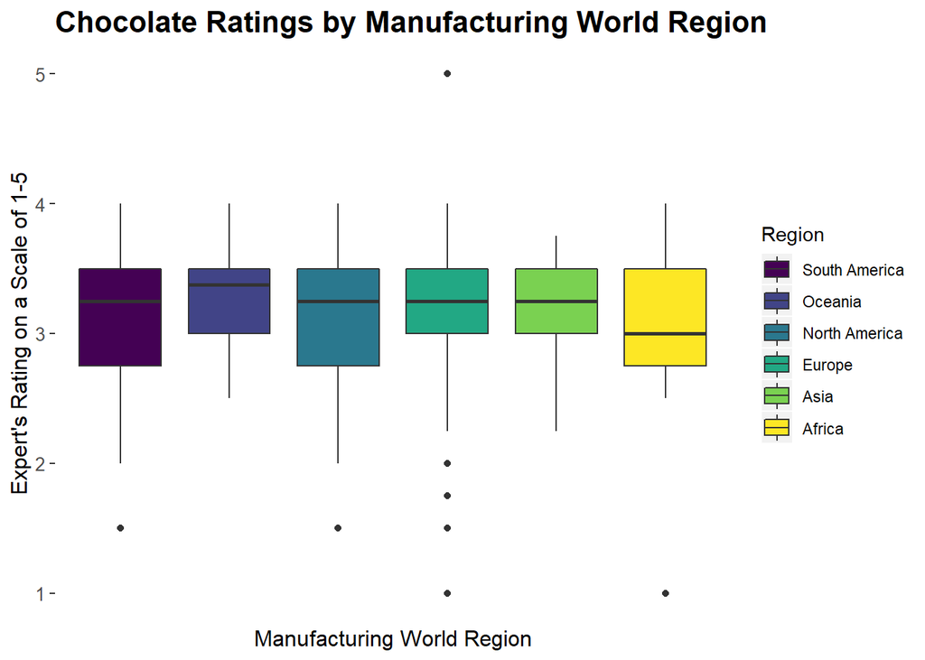

```r
# boxplot(Rating ~ Region, data = Chocolate2, main="Chocolate Ratings by Manufacturing World Region", ylab="Expert's Rating on a Scale of 1-5", xlab="Manufacturing World Region", col = viridis(6), frame=FALSE, xaxt="n")
#legend("bottomright", title="Region",c("South America", "Oceania", "North America", "Europe", "Asia", "Africa"), fill=viridis(6), cex=0.8)


ggplot(data = Chocolate2, aes(x = Region, y = Rating, fill = Region)) +
  geom_boxplot() + scale_fill_viridis(discrete=TRUE) +
  ggtitle("Chocolate Ratings by Manufacturing World Region") +
  theme(plot.title = element_text(hjust = 0, face = "bold", size = (16)),
        panel.background = element_blank(),
        axis.text = element_text(size = (10)),
        axis.title = element_text(size = (12)),
        axis.ticks.x=element_blank(),
        axis.text.x=element_blank()) +
  ylab("Expert's Rating on a Scale of 1-5") +
  xlab("Manufacturing World Region")
```

Visually, the boxplots seem well aligned. Although, some region’s ratings appear more skewed than others. The difference in the regions can be seen better in the five number summary below:

```r
Chocolate2 %>%
  group_by(Region) %>%
  summarise(Min = min(Rating), Q1 = quantile(Rating, 0.25), Med = median(Rating), Mean = mean(Rating), Q3 = quantile(Rating, 0.75), Max = max(Rating)) %>%
  pander()
```

| Region | Min | Q1 | Med | Mean | Q3 | Max |
| --- | --- | --- | --- | --- | --- | --- |
| South America | 1.5 | 2.75 | 3.25 | 3.123 | 3.5 | 4 |
| Oceania | 2.5 | 3 | 3.375 | 3.311 | 3.5 | 4 |
| North America | 1.5 | 2.75 | 3.25 | 3.171 | 3.5 | 4 |
| Europe | 1 | 3 | 3.25 | 3.213 | 3.5 | 5 |
| Asia | 2.25 | 3 | 3.25 | 3.219 | 3.5 | 3.75 |
| Africa | 1 | 2.75 | 3 | 3.04 | 3.5 | 4 |

Europe and Africa had the lowest minumum rating while Oceania had the highest minimum. The medians the ratings of all regions were between 3 and 3.37. The maximum ratings were between 3.75 and 5. Interestingly, Europe which had the lowest minimum also had the highest maximum (5).

#### Kruskal-Wallis Rank Sum Test

A Kruskal-Wallis Rank Sum Test was used to see whether any region’s distribution stochastically different.

```r
# Kruskal-Wallis Rank Sum Test
pander(kruskal.test(Rating~Region, data=Chocolate2))
```

Kruskal-Wallis rank sum test: `Rating` by `Region`

| Test statistic | df | P value |
| --- | --- | --- |
| 13.47 | 5 | 0.01938 * |

While the median ratings of chocolate bars appeared similar, a range of one to five is small enough that tenths and thousandths of a point matter as evidenced by the p-value of 0.01938. There is sufficient evidence to reject the null hypothesis: $p < \alpha$.

## Conclusion

As the p-value is 0.01938, there is sufficient evidence to reject the null. At least one region’s rating is stochastically different. The boxplots indicate that chocolate bars from Africa have the lowest median rating and are right-skewed while the remaining region’s boxplot’s are centered or left-skewed.

[output not shown]